# Cefepime Bayesian Meta-Analysis

#### Does the Trace-Plot Exhibit Convergence?

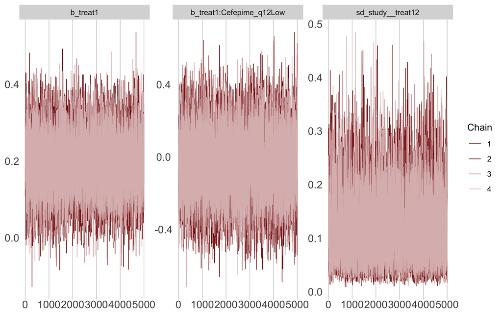

```r
mcmc_trace(cefdose_mod, pars = c("b_treat1",
                                    "b_treat1:Cefepime_q12Low",
                                    "sd_study__treat12"))
```

#### Does the Histogram Have Enough Information?

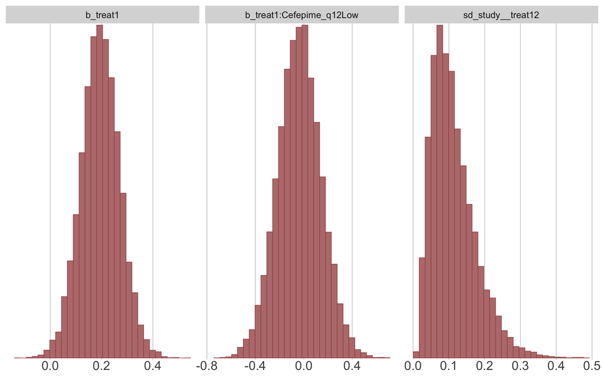

```r
mcmc_hist(cefdose_mod, pars = c("b_treat1",
                                "b_treat1:Cefepime_q12Low",
                                "sd_study__treat12"))
```

#### Do the Chains Exhibit a Strong Degree of Autocorrelation?

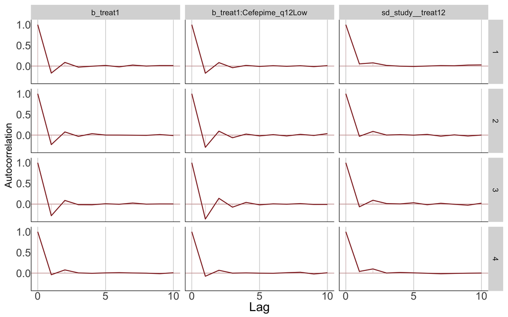

```r
mcmc_acf(cefdose_mod, pars = c("b_treat1",
                                "b_treat1:Cefepime_q12Low",
                                "sd_study__treat12"),
         lags = 10)
```

#### Does the Posterior Distribution Make Substantive Sense?

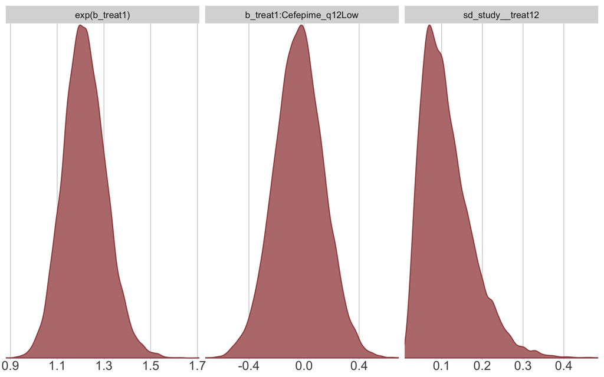

```r
mcmc_dens(cefdose_mod, pars = c("b_treat1",
                                "b_treat1:Cefepime_q12Low",
                                "sd_study__treat12"),
          transformations = list("b_treat1" = "exp"))
```

## 5.5 Risk of Bias

Model formula

```r
# Formula with meta-regression
mf_rob =
  bf(death | trials(N) ~ 1 + study + treat*overall_rob + (treat12 - 1 | study))

#| output: false
# get_prior(mf_rob, data = long_data, family = binomial)
```

Priors

```r
priors_regression_rob =
  # study's baseline (treat = 0) log odds when subgroup == "Low"
  prior(normal(0, 1.5), class = Intercept) +
  prior(normal(0, 1.5), class = b) +
  # treatment effect in reference subgroup "Low", log odds ratio
  prior(normal(0, 0.82), class = b, coef = "treat1") +
  # change in log-odds when treat = 0 for each subgroup
  prior(normal(0, 1.2), class = b, coef = "overall_robHigh") +
  prior(normal(0, 1.2), class = b, coef = "overall_robSomeconcerns") +
  # change in the treatment effect for each subgroup
  prior(normal(0, 0.3), class = b, coef = "treat1:overall_robHigh") +
  prior(normal(0, 0.3), class = b, coef = "treat1:overall_robSomeconcerns") +
  # between-study SD, "tau"
  prior(lognormal(-2.09, 0.705), class = sd)
```

Fit the model only sampling from prior distributions

```r
rob_mod_prior =
  brm(
    sample_prior = "only",
    formula = mf_rob,
    family = binomial,
    prior = priors_regression_rob,
    data = subset(long_data, !is.na(overall_rob)), # remove NA,

    control = list(adapt_delta = .95),
    backend = "cmdstanr", # faster
    cores = parallel::detectCores(),
    chains = 4,
    warmup = 5000,
    iter = 10000,
    seed = 123,
    refresh = 0, # omit sampling text
    file = here("models", "rob_mod_prior.Rds"),
    file_refit = "on_change"
  )
```

Now check if estimand distributions look reasonable (prior predictive check):

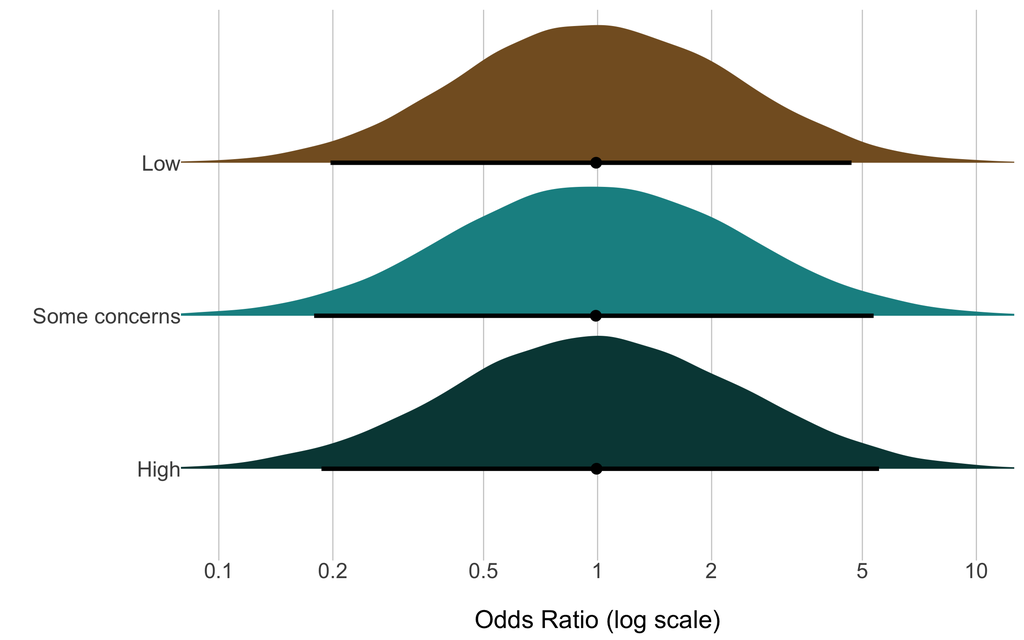

```r
as_draws_df(rob_mod_prior) |>
  reframe("Low" = b_treat1,
          "Some concerns" = b_treat1 + `b_treat1:overall_robSomeconcerns`,
          "High" = b_treat1 + `b_treat1:overall_robHigh`) |>
  pivot_longer(everything()) |>
  mutate(name = factor(name, c("Low",
                               "Some concerns",
                               "High") |> rev()
  )
  ) |>

  ggplot() +
  aes(x = value, y = name, fill = name) +
  stat_halfeye(.width = 0.95,
               point_interval = median_hdi) +
  scale_fill_manual(values=met.brewer("Isfahan1", 3) |> rev()) +
  scale_x_continuous(
    breaks = c(0.1, 0.2, 0.5, 1, 2, 5, 10) |> log(),
    labels = function(x) exp(x)
  ) +
  coord_cartesian(x = c(0.1, 10) |> log())  +
  labs(x = "\nOdds Ratio (log scale)",
       y = " ") +
  theme(legend.position = "none",
        axis.text.y = element_text(hjust = 1))
```

Fit the full model (data + prior)

```r
rob_mod =
  brm(
    formula = mf_rob,
    family = binomial,
    prior = priors_regression_rob,
    data = subset(long_data, !is.na(overall_rob)), # remove NA,

    control = list(adapt_delta = .95),
    backend = "cmdstanr", # faster
    cores = parallel::detectCores(),
    chains = 4,
    warmup = 5000,
    iter = 10000,
    seed = 123,
    refresh = 0, # omit sampling text
    file = here("models", "rob_mod.Rds"),
    file_refit = "on_change"
  )
```

### 5.5.1 Model Diagnostics

Rhat

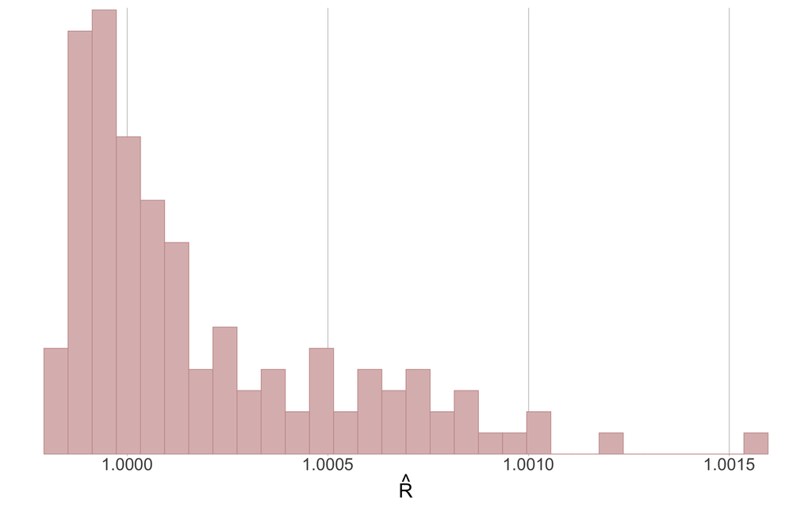

```r
rhat(rob_mod$fit) |>
  mcmc_rhat_hist() +
  theme(legend.position = "none" )
```

Ratios of effective sample size to total sample size

Values are colored using different shades (lighter is better). The chosen thresholds are somewhat arbitrary, but can be useful guidelines in practice.

light: between 0.5 and 1 (high)

mid: between 0.1 and 0.5 (good)

dark: below 0.1 (low)

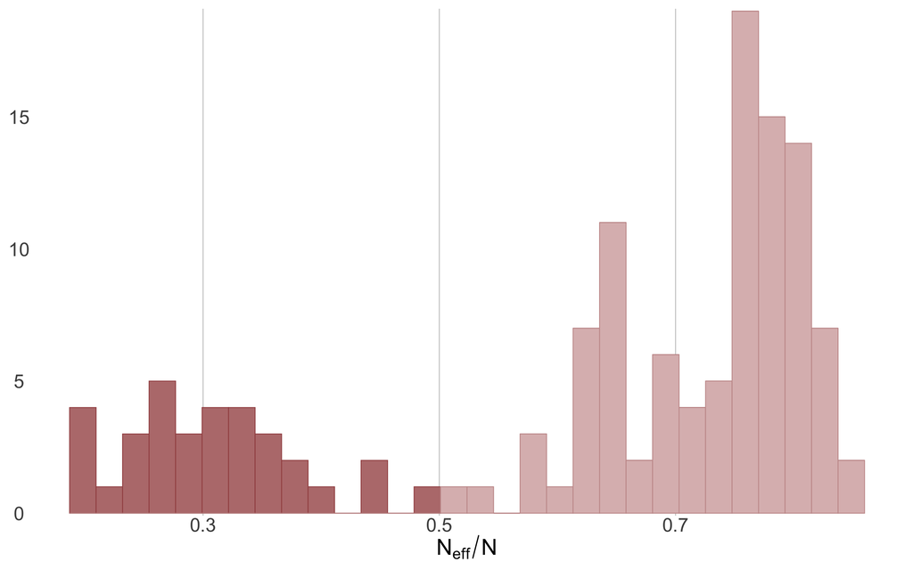

```r
neff_ratio(rob_mod) |>
  mcmc_neff_hist() +
  theme(legend.position = "none" )
```

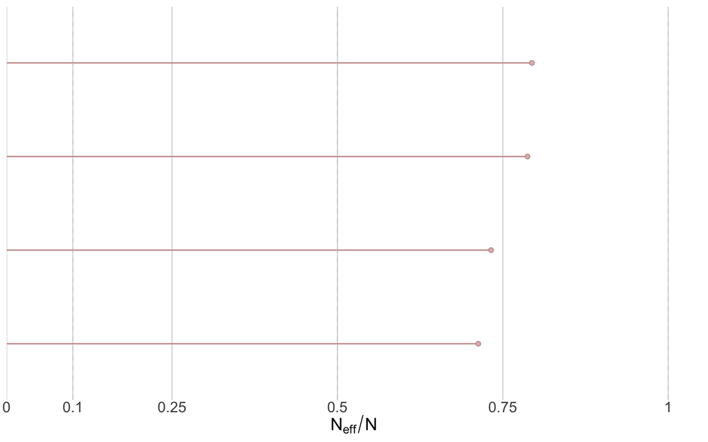

```r
neff_ratio(rob_mod, pars = c("b_treat1",
                             "b_treat1:overall_robSomeconcerns",
                             "b_treat1:overall_robHigh",
                             "sd_study__treat12")) |>
  mcmc_neff() +
  theme(legend.position = "none" )
```

#### Does the Trace-Plot Exhibit Convergence?

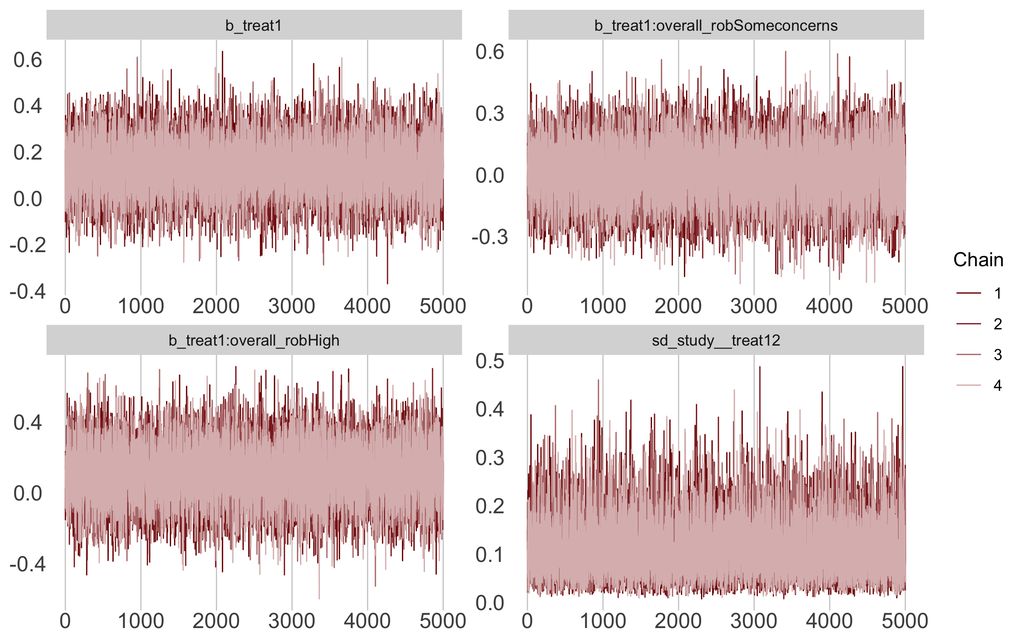

```r
mcmc_trace(rob_mod, pars = c("b_treat1",
                             "b_treat1:overall_robSomeconcerns",
                             "b_treat1:overall_robHigh",
                             "sd_study__treat12"))
```

#### Does the Histogram Have Enough Information?

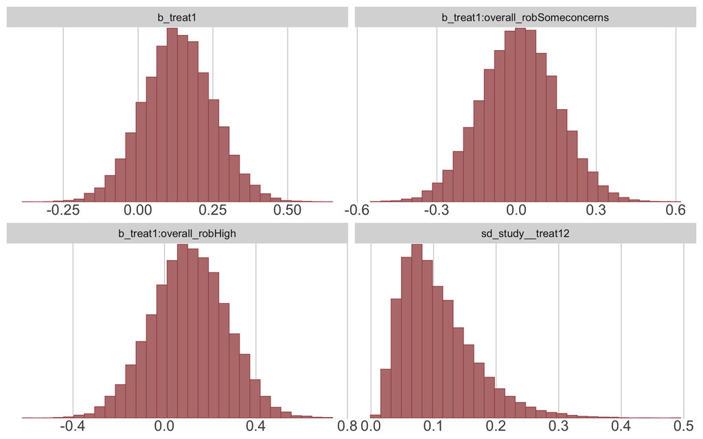

```r
mcmc_hist(rob_mod, pars = c("b_treat1",
                             "b_treat1:overall_robSomeconcerns",
                             "b_treat1:overall_robHigh",
                             "sd_study__treat12"))
```

#### Do the Chains Exhibit a Strong Degree of Autocorrelation?

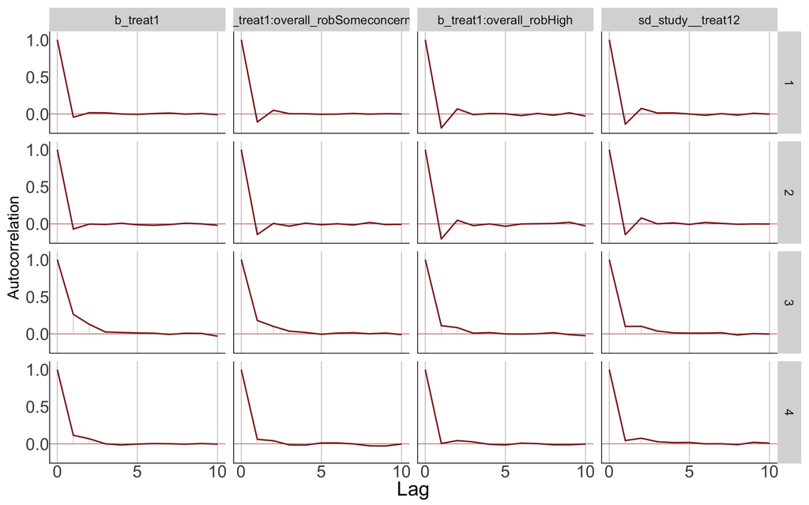

```r
mcmc_acf(rob_mod, pars = c("b_treat1",
                             "b_treat1:overall_robSomeconcerns",
                             "b_treat1:overall_robHigh",
                             "sd_study__treat12"),
         lags = 10)
```

#### Does the Posterior Distribution Make Substantive Sense?

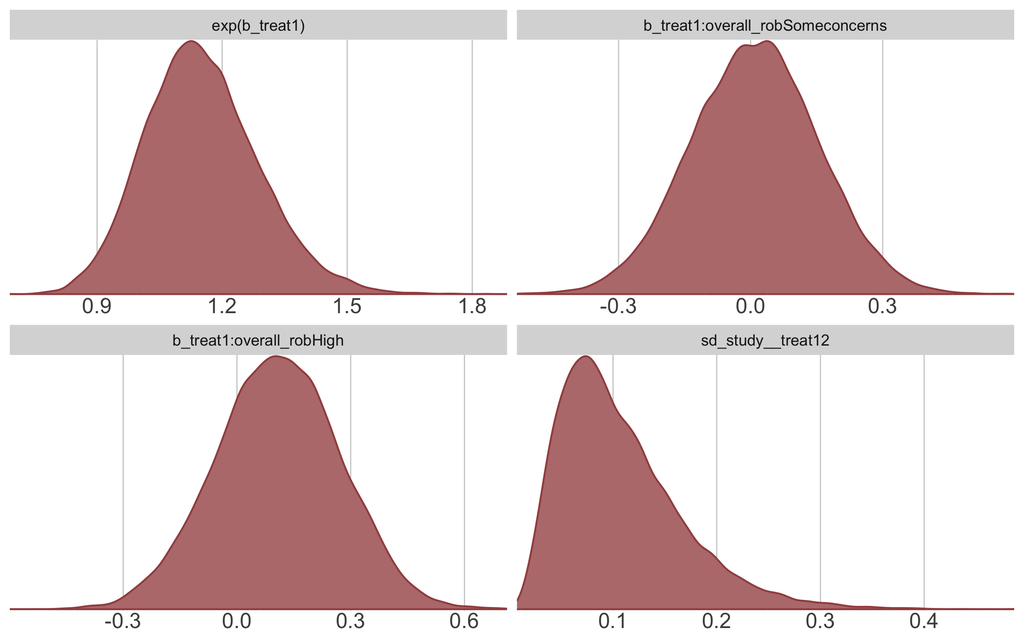

```r
mcmc_dens(rob_mod, pars = c("b_treat1",
                             "b_treat1:overall_robSomeconcerns",
                             "b_treat1:overall_robHigh",
                             "sd_study__treat12"),
          transformations = list("b_treat1" = "exp"))
```

# 6 Published vs. Unpublished

## 6.1 Data

```r
filtered_data_publish =
  data |>
  filter(N_cef != "NA") |>  # exclude studies with missing data
  rename("death_com" = deaths_com,
         "study" = Study.ID) |>
  mutate(publish = ifelse(Comparator == "Control", "Unpublished", "Published"))

long_data_publish =
  filtered_data_publish |>
  pivot_longer(
   cols = c(death_cef, death_com, N_cef, N_com),
   names_to = c(".value", "group"),
   names_sep = "_"
) |>
  # important for model fitting
  mutate(study = factor(study),
         treat = ifelse(group == "com", 0, 1) |> factor(levels = c("0", "1")),
         treat12 = ifelse(group == "com", -0.5, 0.5),

         publish = factor(publish,
                             levels = c("Published",
                                        "Unpublished"))
         )
```

## 6.2 Overall Model

Model formula

```r
# Model 4 in DOI: 10.1002/sim.7588
mf =
  bf(death | trials(N) ~ 1 + study + treat + (treat12 - 1 | study))
```

Priors

```r
# get_prior(mf, family = binomial, data = long_data_publish)
```

```r
informative = bayesmeta::TurnerEtAlPrior("all-cause mortality",
                                         "pharma",
                                         "pharma")


logmean = informative$parameters["tau", "mu"]
logsd = informative$parameters["tau", "sigma"]

# logmean
# -2.09

# logsd
# 0.705

priors_overall =
  # study's baseline (treat = 0) log odds
   prior(normal(0, 1.5), class = Intercept) +
  prior(normal(0, 1.5), class = b) +
  # overall treatment effect, log odds ratio, "theta"
  prior(normal(0, 0.82), class = b, coef = "treat1") +
  # between-study SD, "tau"
  prior(lognormal(-2.09, 0.705), class = sd)
```

Fit the model only sampling from prior distributions

```r
publish_overall_mod_prior =
  brm(
    sample_prior = "only",
    formula = mf,
    family = binomial,
    prior = priors_overall,
    data = long_data_publish,

    control = list(adapt_delta = .95),
    backend = "cmdstanr", # faster
    cores = parallel::detectCores(),
    chains = 4,
    warmup = 5000,
    iter = 10000,
    seed = 123,
    refresh = 0, # omit sampling text
    file = here("models", "publish_overall_mod_prior.Rds"),
    file_refit = "on_change"
)
```

Now check if the estimand distribution looks reasonable (prior predictive check):

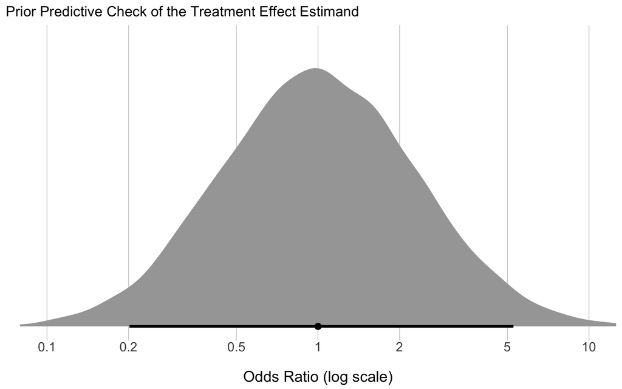

```r
as_draws_df(publish_overall_mod_prior) |>
  ggplot() +
  aes(x = b_treat1) +
  stat_halfeye(.width = 0.95,
               point_interval = median_hdi) +
  scale_x_continuous(
    breaks = c(0.1, 0.2, 0.5, 1, 2, 5, 10) |> log(),
    labels = function(x) exp(x)
    ) +
  coord_cartesian(x = c(0.1, 10) |> log())  +
  labs(x = "\nOdds Ratio (log scale)",
       y = " ",
       title = "Prior Predictive Check of the Treatment Effect Estimand") +
  theme(axis.text.y = element_blank())
```

Fit the full model (data + prior)

```r
publish_overall_mod =
  brm(
    formula = mf,
    family = binomial,
    prior = priors_overall,
    data = long_data_publish,

    control = list(adapt_delta = .95),
    backend = "cmdstanr", # faster
    cores = parallel::detectCores(),
    chains = 4,
    warmup = 5000,
    iter = 10000,
    seed = 123,
    refresh = 0, # omit sampling text
    file = here("models", "publish_overall_mod.Rds"),
    file_refit = "on_change"
)
```

## 6.3 Model Diagnostics

Rhat

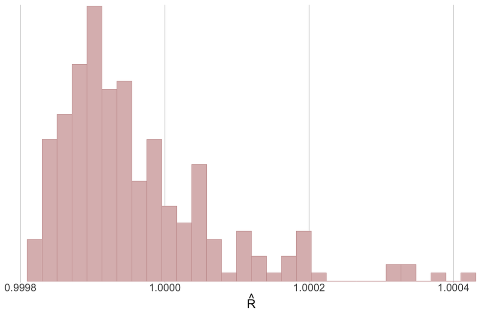

```r
rhat(publish_overall_mod$fit) |>
  mcmc_rhat_hist() +
  theme(legend.position = "none" )
```

Ratios of effective sample size to total sample size

Values are colored using different shades (lighter is better). The chosen thresholds are somewhat arbitrary, but can be useful guidelines in practice.

light: between 0.5 and 1 (high)

mid: between 0.1 and 0.5 (good)

dark: below 0.1 (low)

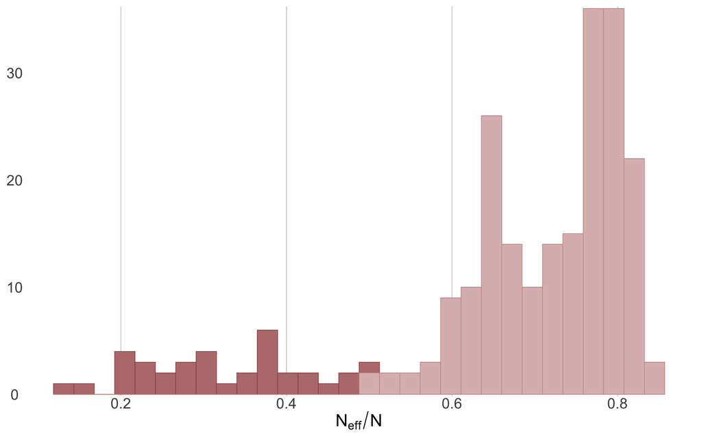

```r
neff_ratio(publish_overall_mod) |>
  mcmc_neff_hist() +
  theme(legend.position = "none" )
```

### 6.3.1 Does the Trace-Plot Exhibit Convergence?

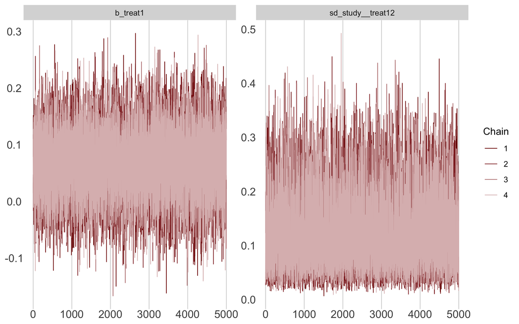

```r
mcmc_trace(publish_overall_mod, pars = c("b_treat1","sd_study__treat12"))
```

### 6.3.2 Does the Histogram Have Enough Information?

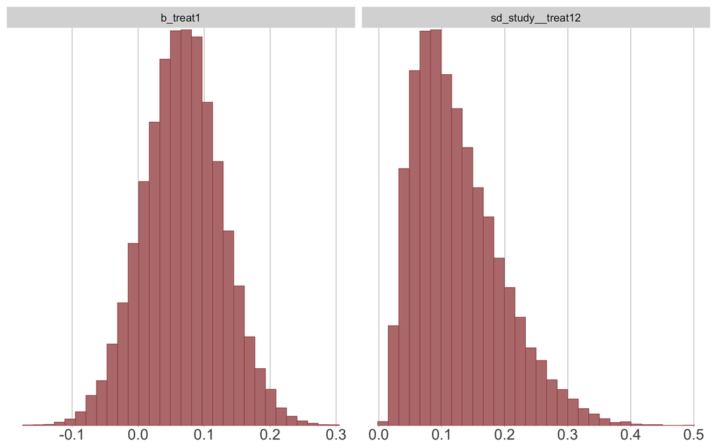

```r
mcmc_hist(publish_overall_mod, pars = c("b_treat1","sd_study__treat12"))
```

### 6.3.3 Do the Chains Exhibit a Strong Degree of Autocorrelation?

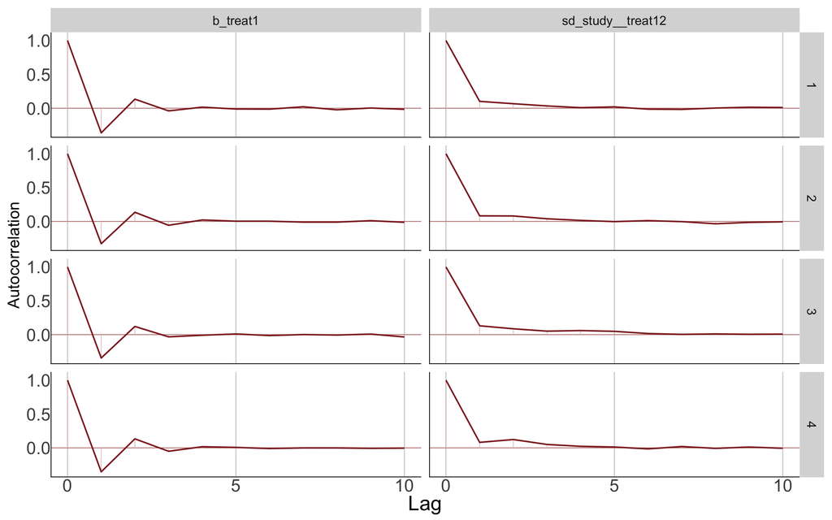

```r
mcmc_acf(publish_overall_mod, pars = c("b_treat1","sd_study__treat12"),
         lags = 10)
```

### 6.3.4 Does the Posterior Distribution Make Substantive Sense?

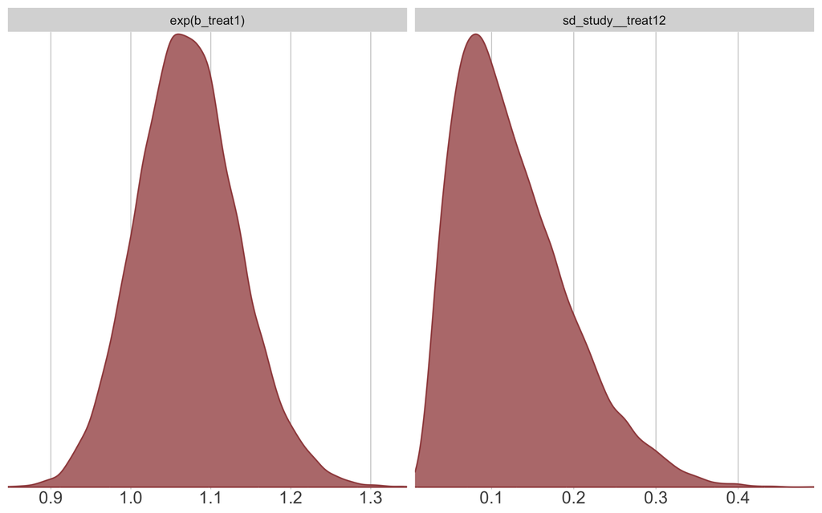

```r
mcmc_dens(publish_overall_mod,
          pars = c("b_treat1","sd_study__treat12"),
          transformations = list("b_treat1" = "exp"))
```

## 6.4 Meta-Regressions

Model formula

```r
# Formula with meta-regression
mf_publish =
  bf(death | trials(N) ~ 1 + study + treat*publish + (treat12 - 1 | study))

#| output: false
# get_prior(mf_publish, data = long_data_publish, family = binomial)
```

Priors

```r
priors_regression_publish =
  # study's baseline (treat = 0) log odds, when subgroup == "Published"
  prior(normal(0, 1.5), class = Intercept) +
  prior(normal(0, 1.5), class = b) +
  # treatment effect in reference subgroup "Published", log odds ratio
  prior(normal(0, 0.82), class = b, coef = "treat1") +
  # change in log-odds when treat = 0 for subgroup "Unpublished"
  prior(normal(0, 1.2), class = b, coef = "publishUnpublished") +
  # change in the treatment effect for subgroup "Unpublished" compared to "Published"
  prior(normal(0, 0.3), class = b, coef = "treat1:publishUnpublished") +
  # between-study SD, "tau"
  prior(lognormal(-2.09, 0.705), class = sd)
```

Fit the model only sampling from prior distributions

```r
publish_subgroup_mod_prior =
  brm(
    sample_prior = "only",
    formula = mf_publish,
    family = binomial,
    prior = priors_regression_publish,
    data = long_data_publish,

    control = list(adapt_delta = .95),
    backend = "cmdstanr", # faster
    cores = parallel::detectCores(),
    chains = 4,
    warmup = 5000,
    iter = 10000,
    seed = 123,
    refresh = 0, # omit sampling text
    file = here("models", "publish_subgroup_mod_prior.Rds"),
    file_refit = "on_change"
  )
```

Now check if estimand distributions look reasonable (prior predictive check):

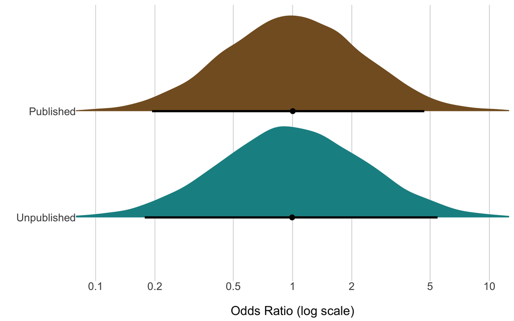

```r
as_draws_df(publish_subgroup_mod_prior) |>
  reframe("Published" = b_treat1,
          "Unpublished" = b_treat1 + `b_treat1:publishUnpublished`) |>
  pivot_longer(everything()) |>
  mutate(name = factor(name, levels = c("Published",
                                        "Unpublished") |> rev()
  )
  ) |>

  ggplot() +
  aes(x = value, y = name, fill = name) +
  stat_halfeye(.width = 0.95,
               point_interval = median_hdi) +
  scale_fill_manual(values=met.brewer("Isfahan1", 2) |> rev()) +
  scale_x_continuous(
    breaks = c(0.1, 0.2, 0.5, 1, 2, 5, 10) |> log(),
    labels = function(x) exp(x)
  ) +
  coord_cartesian(x = c(0.1, 10) |> log())  +
  labs(x = "\nOdds Ratio (log scale)",
       y = " ") +
  theme(legend.position = "none",
        axis.text.y = element_text(hjust = 1))
```

Fit the full model (data + prior)

```r
publish_subgroup_mod =
  brm(
    formula = mf_publish,
    family = binomial,
    prior = priors_regression_publish,
    data = long_data_publish,

    control = list(adapt_delta = .95),
    backend = "cmdstanr", # faster
    cores = parallel::detectCores(),
    chains = 4,
    warmup = 5000,
    iter = 10000,
    seed = 123,
    refresh = 0, # omit sampling text
    file = here("models", "publish_subgroup_mod.Rds"),
    file_refit = "on_change"
  )
```

### 6.4.1 Model Diagnostics

Rhat

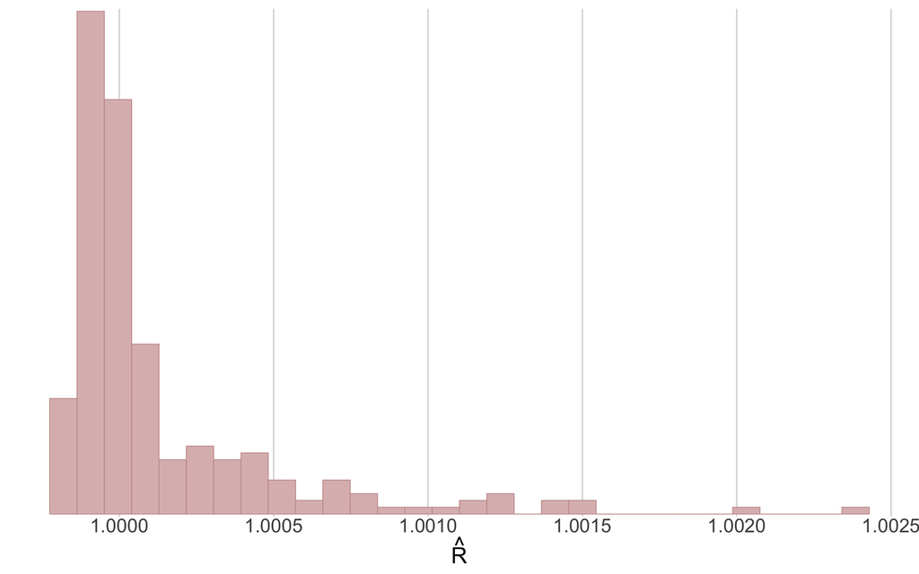

```r
rhat(publish_subgroup_mod$fit) |>
  mcmc_rhat_hist() +
  theme(legend.position = "none" )
```

Ratios of effective sample size to total sample size

Values are colored using different shades (lighter is better). The chosen thresholds are somewhat arbitrary, but can be useful guidelines in practice.

light: between 0.5 and 1 (high)

mid: between 0.1 and 0.5 (good)

dark: below 0.1 (low)

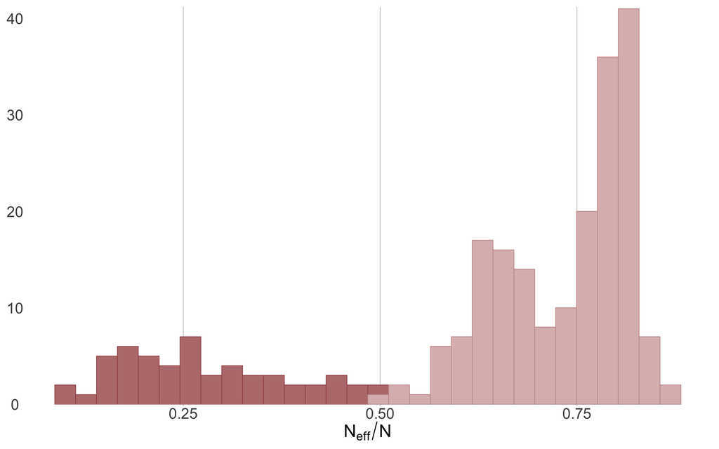

```r
neff_ratio(publish_subgroup_mod) |>
  mcmc_neff_hist() +
  theme(legend.position = "none" )
```

#### Does the Trace-Plot Exhibit Convergence?

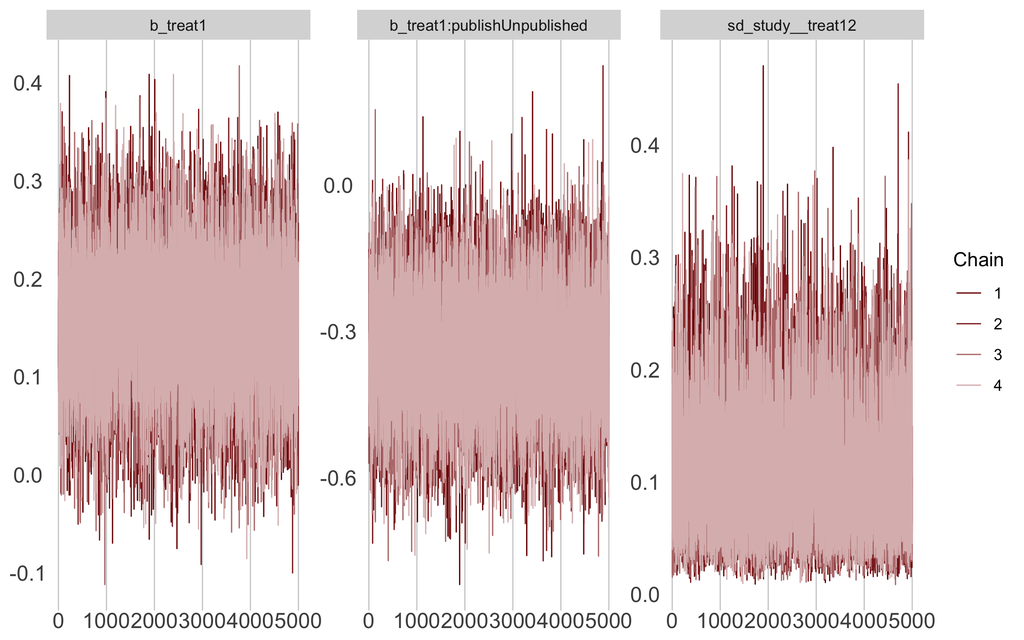

```r
mcmc_trace(publish_subgroup_mod,
           pars = c("b_treat1",
                    "b_treat1:publishUnpublished",
                    "sd_study__treat12"))
```

#### Does the Histogram Have Enough Information?

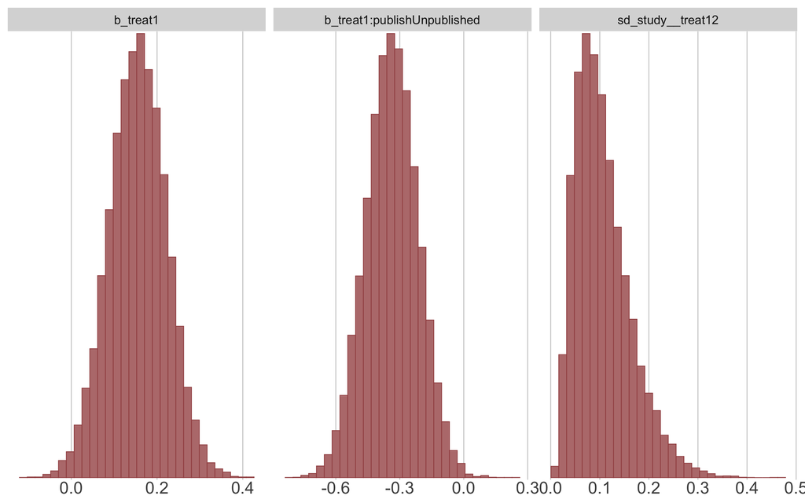

```r
mcmc_hist(publish_subgroup_mod,
           pars = c("b_treat1",
                    "b_treat1:publishUnpublished",
                    "sd_study__treat12"))
```

#### Do the Chains Exhibit a Strong Degree of Autocorrelation?

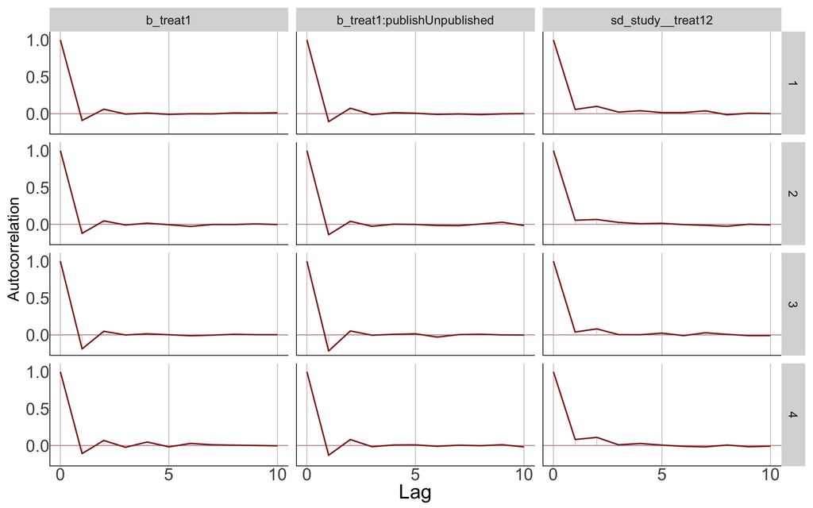

```r
mcmc_acf(publish_subgroup_mod,
           pars = c("b_treat1",
                    "b_treat1:publishUnpublished",
                    "sd_study__treat12"),
         lags = 10)
```

#### Does the Posterior Distribution Make Substantive Sense?

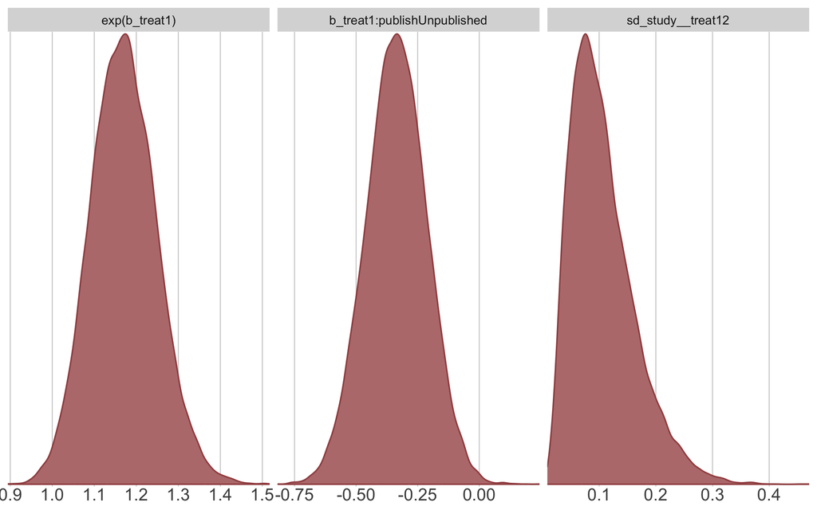

```r
mcmc_dens(publish_subgroup_mod,
           pars = c("b_treat1",
                    "b_treat1:publishUnpublished",
                    "sd_study__treat12"),
          transformations = list("b_treat1" = "exp"))
```